Load Required Packages:

```r
library(ggplot2)
library(dplyr)
```

# 1 Exercise 1: Modify Plot Background and Grid

**Dataset:** `mtcars` (available within R).

**Task:** Create a scatter plot of `mpg` against `hp` from the `mtcars` dataset. Adjust the theme to: 1. Set the plot background to “lightblue”. 2. Change major grid lines to “white”. 3. Remove minor grid lines and axis ticks.

**Functions to Use:** `ggplot()`, `aes()`, `geom_point()`, `theme()`, `element_rect()`, `element_line()`, `element_blank()`

**Solution:**

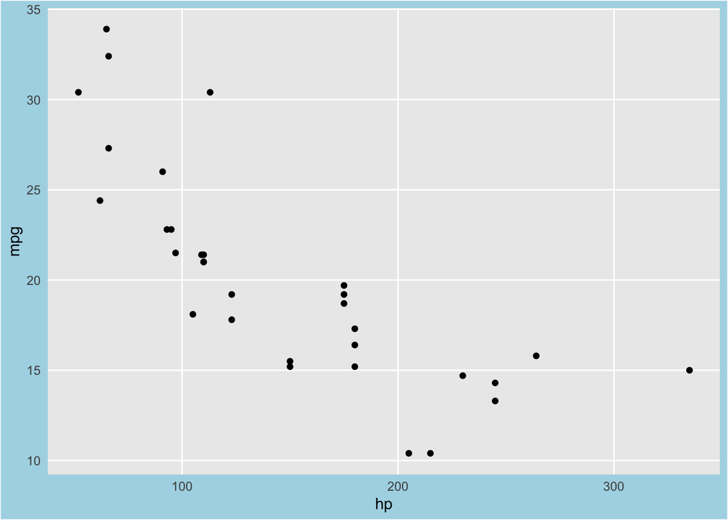

```r
plot1 <- ggplot(mtcars, aes(x = hp, y = mpg)) +
  geom_point() +
  theme(
    plot.background = element_rect(fill = "lightblue"),
    panel.grid.major = element_line(color = "white"),
    panel.grid.minor = element_blank(),
    axis.ticks = element_blank()
  )

print(plot1)
```

# 2 Exercise 2: Change Title and Axis Text Styles

**Dataset:** `diamonds` (available within the `ggplot2` package).

**Task:** Plot `price` against `carat` from the `diamonds` dataset. Customize the theme to: 1. Bolden and color the plot title “red”. 2. Italicize the axis text.

**Functions to Use:** `ggplot()`, `aes()`, `geom_point()`, `ggtitle()`, `theme()`, `element_text()`

**Solution:**

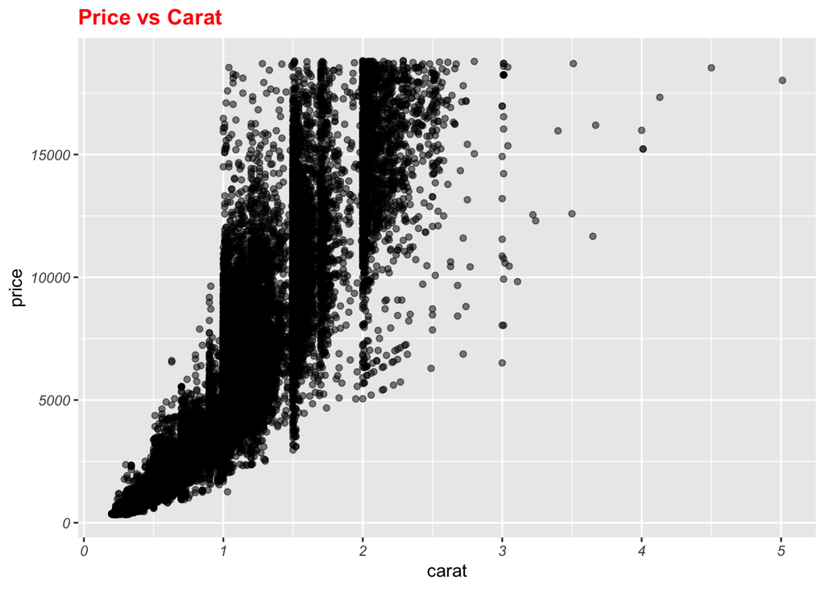

```r
plot2 <- ggplot(diamonds, aes(x = carat, y = price)) +
  geom_point(alpha = 0.5) +
  ggtitle("Price vs Carat") +
  theme(
    plot.title = element_text(face = "bold", color = "red"),
    axis.text = element_text(face = "italic")
  )

print(plot2)
```

# 3 Exercise 3: Alter Legend Properties

**Dataset:** `iris` (available within R).

**Task:** Develop a scatter plot of `Sepal.Length` against `Sepal.Width`, colored by `Species`. Adjust the theme to: 1. Place the legend at the bottom. 2. Fill the legend background with “grey90”. 3. Change legend title text to be bold and blue.

**Functions to Use:** `ggplot()`, `aes()`, `geom_point()`, `theme()`, `element_rect()`, `element_text()`

**Solution:**

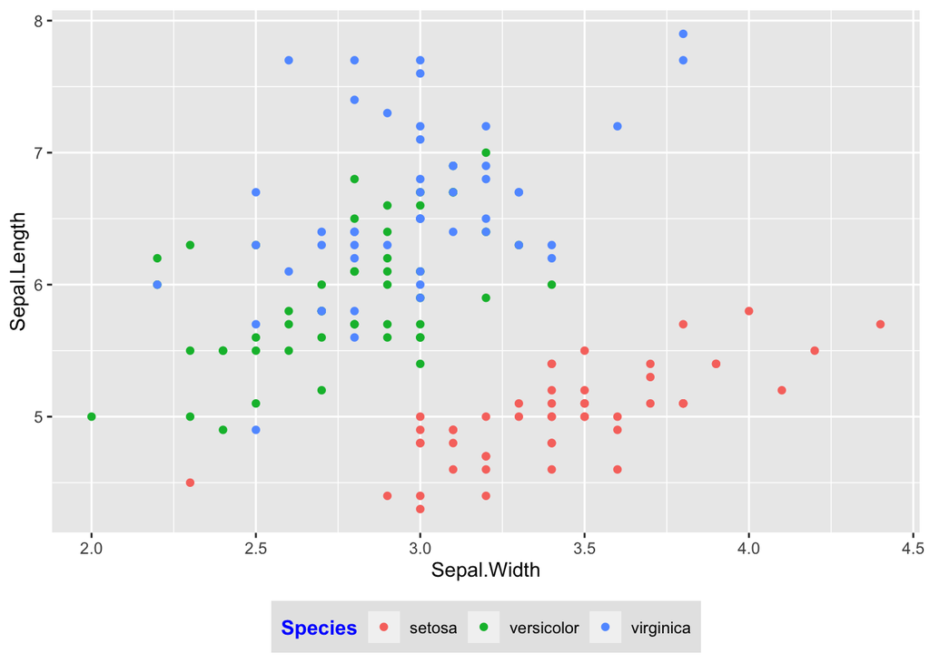

```r
plot3 <- ggplot(iris, aes(x = Sepal.Width, y = Sepal.Length, color = Species)) +
  geom_point() +
  theme(
    legend.position = "bottom",
    legend.background = element_rect(fill = "grey90"),
    legend.title = element_text(face = "bold", color = "blue")
  )

print(plot3)
```

# 4 Exercise 4: Adjust Axis Line Appearance and Title Position

**Dataset:** Fictitious dataset of monthly sales.

**Load Dataset:**

```r
sales_data <- data.frame(
  month = month.abb,
  sales = c(500, 520, 515, 530, 535, 545, 560, 575, 580, 590, 600, 610)
)
```

**Functions to Use:** `ggplot()`, `aes()`, `geom_line()`, `geom_point()`, `ggtitle()`, `theme()`, `element_line()`

**Solution:**

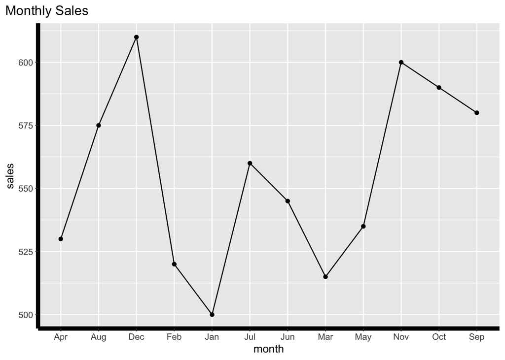

```r
plot4 <- ggplot(sales_data, aes(x = month, y = sales)) +
  geom_line(group = 1) +
  geom_point() +
  ggtitle("Monthly Sales") +
  theme(
    axis.line = element_line(size = 2),
    plot.title.position = "plot"
  )
print(plot4)
```

# 5 Exercise 5: Adjusting Strip Text in Facets

**Dataset:** `mpg` (available within the `ggplot2` package).

**Task:** Create a scatter plot of `hwy` against `displ` from the `mpg` dataset. Facet the plot by `class`. Adjust the theme to: 1. Color the strip text in “white”. 2. Set the strip background to “darkblue”.

**Functions to Use:** `ggplot()`, `aes()`, `geom_point()`, `facet_wrap()`, `theme()`, `element_text()`, `element_rect()`

**Solution:**

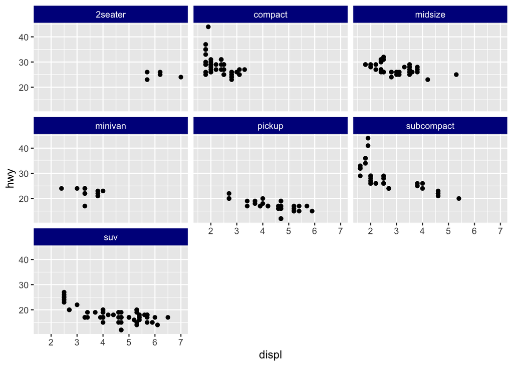

```r
plot5 <- ggplot(mpg, aes(x = displ, y = hwy)) +
  geom_point() +
  facet_wrap(~class) +
  theme(
    strip.text = element_text(color = "white"),
    strip.background = element_rect(fill = "darkblue")
  )

print(plot5)
```

# 6 Exercise 6: Modify Legend Key Shapes

**Dataset:** `iris` (available within R).

**Task:** Create a scatter plot of `Sepal.Length` against `Sepal.Width`, colored by `Species`. Adjust the theme to: 1. Use square shape keys in the legend.

**Functions to Use:** `ggplot()`, `aes()`, `geom_point()`, `theme()`, `guide_legend()`, `override.aes`

**Solution:**

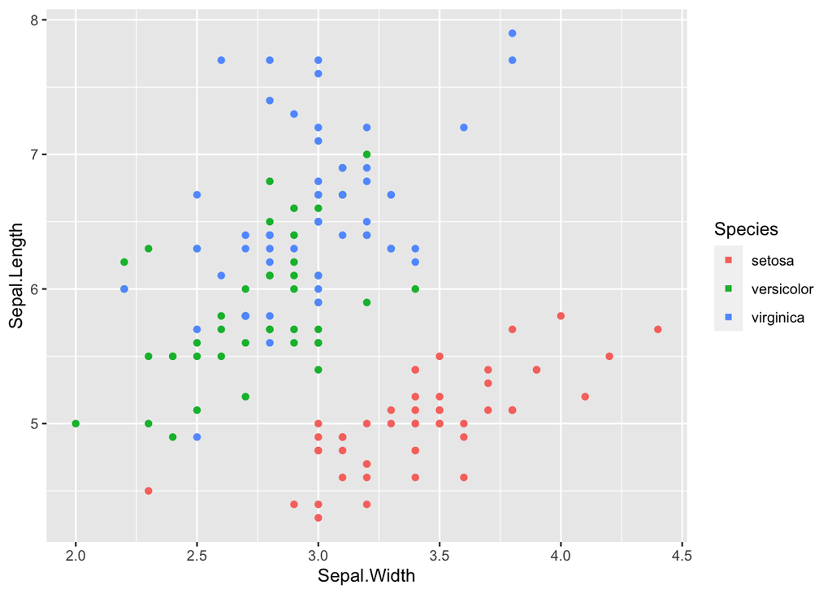

```r
plot6 <- ggplot(iris, aes(x = Sepal.Width, y = Sepal.Length, color = Species)) +
  geom_point() +
  theme(
    legend.key = element_rect()
  ) +
  guides(
    color = guide_legend(override.aes = list(shape = 15))
  )

print(plot6)
```

# 7 Exercise 7: Custom Axis Ticks and Labels

**Dataset:** `diamonds` (available within the `ggplot2` package).

**Task:** Plot `price` against `carat` from the `diamonds` dataset. Customize the theme to: 1. Increase the size of x-axis tick marks. 2. Color y-axis tick text to “red”.

**Functions to Use:** `ggplot()`, `aes()`, `geom_point()`, `theme()`, `element_line()`, `element_text()`

**Solution:**

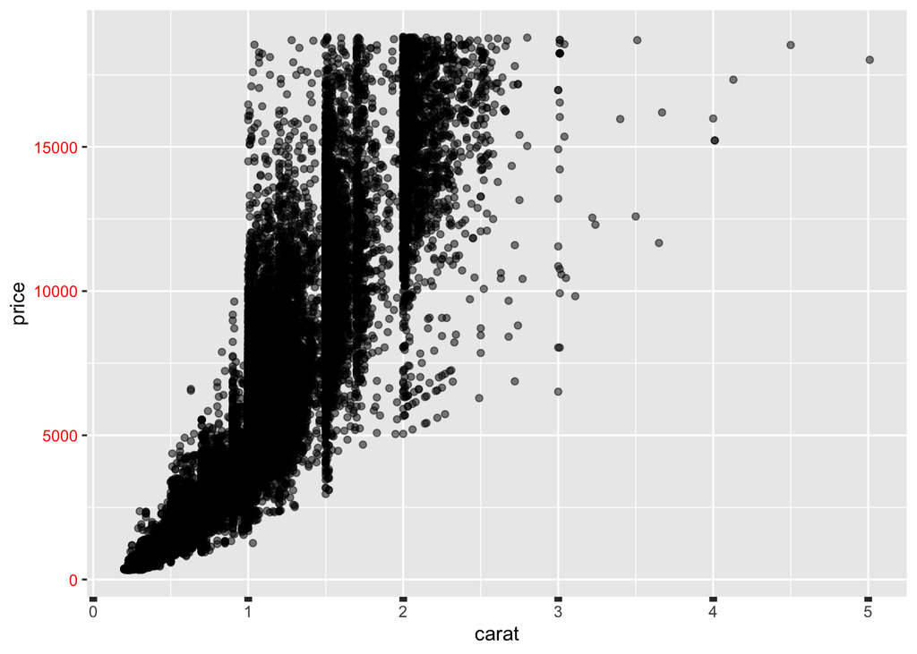

```r
plot7 <- ggplot(diamonds, aes(x = carat, y = price)) +
  geom_point(alpha = 0.5) +
  theme(
    axis.ticks.x = element_line(size = 2),
    axis.text.y = element_text(color = "red")
  )

print(plot7)
```

# 8 Exercise 8: Modify Plot Margins

**Dataset:** `airquality` (available within R).

**Functions to Use:** `ggplot()`, `aes()`, `geom_point()`, `theme()`, `margin()`

**Solution:**

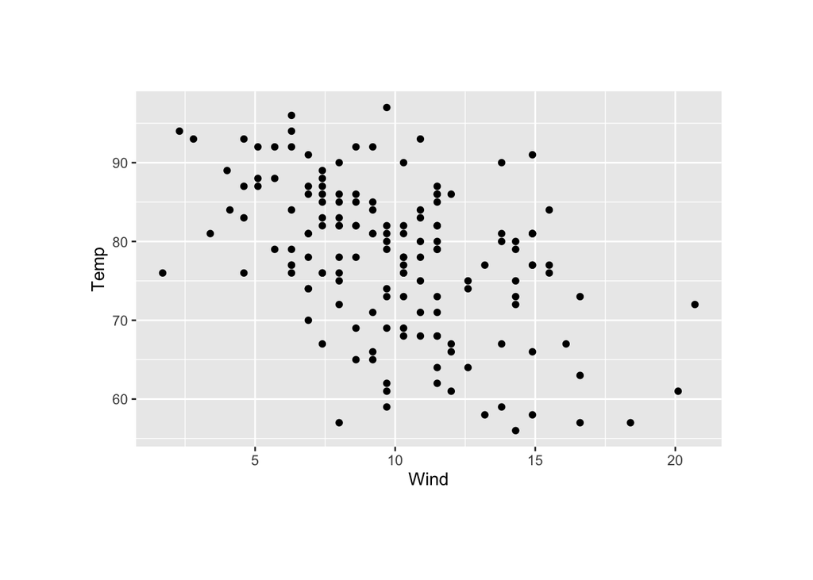

```r
plot8 <- ggplot(airquality, aes(x = Wind, y = Temp)) +
  geom_point() +
  theme(
    plot.margin = margin(2, 2, 2, 2, "cm")
  )

print(plot8)
```

# 9 Exercise 9: Remove Plot Labels

**Dataset:** Fictitious dataset of weekly sales.

**Task:** Plot sales across weeks. Customize the theme to: 1. Remove axis title and plot title.

**Load Dataset:**

```r
sales_weekly <- data.frame(
  week = 1:52,
  sales = rnorm(52, 550, 25)
)
```

**Functions to Use:** `ggplot()`, `aes()`, `geom_line()`, `theme()`, `element_blank()`

**Solution:**

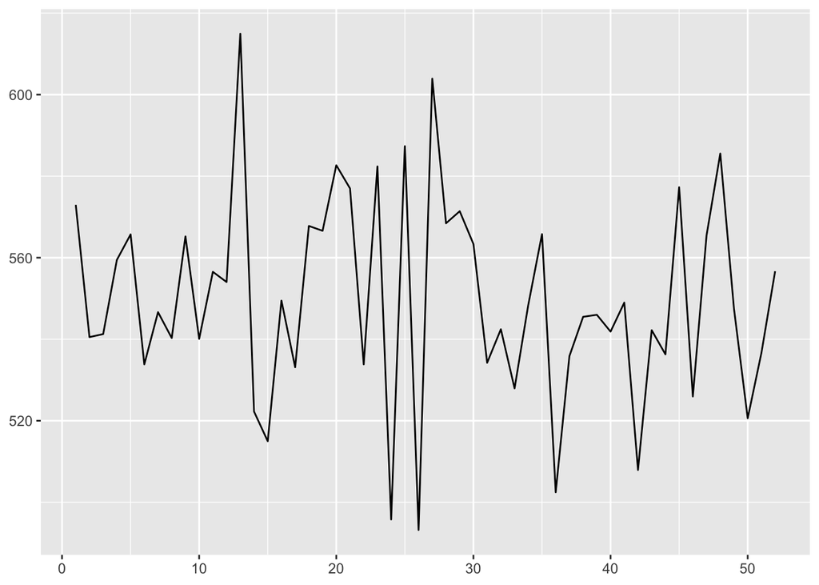

```r
plot9 <- ggplot(sales_weekly, aes(x = week, y = sales)) +
  geom_line() +
  ggtitle("Weekly Sales") +
  theme(
    plot.title = element_blank(),
    axis.title.x = element_blank(),
    axis.title.y = element_blank()
  )

print(plot9)
```

.